# Practical Machine Learning Project

David Faria

January 31, 2016

# Loading Data

#### Reading a few lines to get an idea of the data

```r
readLines("pml-training.csv",n=5)
readLines("pml-training.csv",n=-5)
```

Missing values coded as NA, separator=“,” and text coded as “"

```r
train <- read.csv("pml-training.csv", na.strings = c("NA"))
```

Using str(train) shows thatA lot of variables are coded as factor, while most of their levels are numeric. There seems to be “#DIV/0!” in the data.Reloading the data with this subtleties:

```r
train <- read.csv("pml-training.csv", na.strings = c("NA","#DIV/0!"))
#seems to be ok now, loading testing data with these parameters
test <- read.csv("pml-testing.csv", na.strings = c("NA","#DIV/0!"))
```

# Cleaning and checking data

### Further data quality and transformation checks

Checking for missing values:

```r
NApercentages<-colSums(is.na(train))/nrow(train)
# How many variables have mainly unknown values?
sum(NApercentages>=0.95) #100 variables! a lot
```

```
## [1] 100
```

```r
# There is not much to do with these variables: filtering them out
train <- train[,NApercentages<=0.95]
dim(train) #Only 60 variables remaining
```

```
## [1] 19622    60
```

```r
# Checking
NApercentages2<-colSums(is.na(train))/nrow(train)
NApercentages2 #No more NA values
```

```
##                    X            user_name raw_timestamp_part_1
##                    0                    0                    0
## raw_timestamp_part_2       cvtd_timestamp           new_window
##                    0                    0                    0
##           num_window            roll_belt           pitch_belt
##                    0                    0                    0
##             yaw_belt     total_accel_belt         gyros_belt_x
##                    0                    0                    0
##         gyros_belt_y         gyros_belt_z         accel_belt_x
##                    0                    0                    0
##         accel_belt_y         accel_belt_z        magnet_belt_x
##                    0                    0                    0
##        magnet_belt_y        magnet_belt_z             roll_arm
##                    0                    0                    0
##            pitch_arm              yaw_arm      total_accel_arm
##                    0                    0                    0
##          gyros_arm_x          gyros_arm_y          gyros_arm_z
##                    0                    0                    0
##          accel_arm_x          accel_arm_y          accel_arm_z
##                    0                    0                    0
##         magnet_arm_x         magnet_arm_y         magnet_arm_z
##                    0                    0                    0
##        roll_dumbbell       pitch_dumbbell         yaw_dumbbell
##                    0                    0                    0
## total_accel_dumbbell     gyros_dumbbell_x     gyros_dumbbell_y
##                    0                    0                    0
##     gyros_dumbbell_z     accel_dumbbell_x     accel_dumbbell_y
##                    0                    0                    0
##     accel_dumbbell_z    magnet_dumbbell_x    magnet_dumbbell_y
##                    0                    0                    0
##    magnet_dumbbell_z         roll_forearm        pitch_forearm
##                    0                    0                    0
##          yaw_forearm  total_accel_forearm      gyros_forearm_x
##                    0                    0                    0
##      gyros_forearm_y      gyros_forearm_z      accel_forearm_x
##                    0                    0                    0
##      accel_forearm_y      accel_forearm_z     magnet_forearm_x
##                    0                    0                    0
##     magnet_forearm_y     magnet_forearm_z               classe
##                    0                    0                    0
```

Variables that had more than 95% of missing values are not useful for prediction for many reasons, but mainly: * They have no variance * Their frequency ratio is extremely low * Even if missing values meant something, it is most likely that it is not useful.

So, the same rules coming from the train set are applied to the test se. No checks are performed over the test set, or it would bias our anaysis.

```r
test <- test[,NApercentages<=0.95]
```

Checking data closely now that less variables are to be analyzed:

```r
str(train)
```

```
## 'data.frame':    19622 obs. of  60 variables:
##  $ X                   : int  1 2 3 4 5 6 7 8 9 10 ...
##  $ user_name           : Factor w/ 6 levels "adelmo","carlitos",..: 2 2 2 2 2 2 2 2 2 2 ...
##  $ raw_timestamp_part_1: int  1323084231 1323084231 1323084231 1323084232 1323084232 1323084232 1323084232 1323084232 1323084232 1323084232 ...
##  $ raw_timestamp_part_2: int  788290 808298 820366 120339 196328 304277 368296 440390 484323 484434 ...
##  $ cvtd_timestamp      : Factor w/ 20 levels "02/12/2011 13:32",..: 9 9 9 9 9 9 9 9 9 9 ...
##  $ new_window          : Factor w/ 2 levels "no","yes": 1 1 1 1 1 1 1 1 1 1 ...
##  $ num_window          : int  11 11 11 12 12 12 12 12 12 12 ...
##  $ roll_belt           : num  1.41 1.41 1.42 1.48 1.48 1.45 1.42 1.42 1.43 1.45 ...
##  $ pitch_belt          : num  8.07 8.07 8.07 8.05 8.07 8.06 8.09 8.13 8.16 8.17 ...
##  $ yaw_belt            : num  -94.4 -94.4 -94.4 -94.4 -94.4 -94.4 -94.4 -94.4 -94.4 -94.4 ...
##  $ total_accel_belt    : int  3 3 3 3 3 3 3 3 3 3 ...
##  $ gyros_belt_x        : num  0 0.02 0 0.02 0.02 0.02 0.02 0.02 0.02 0.03 ...
##  $ gyros_belt_y        : num  0 0 0 0 0.02 0 0 0 0 0 ...
##  $ gyros_belt_z        : num  -0.02 -0.02 -0.02 -0.03 -0.02 -0.02 -0.02 -0.02 -0.02 0 ...
```

[output cut: 46 more lines]

Some variables seem to have no use, such as the “X” variable. It’s an index so let’s filter it out.

```r
train <- train[,names(train)!="X"]
test <- test[,names(test)!="X"]
```

# Analysing variables

#### Performing some quick visualization over factor variables

There are just a few of them:

```r
names(train)[sapply(train,is.factor)]
```

```
## [1] "user_name"      "cvtd_timestamp" "new_window"     "classe"
```

So what about the **classe** variable to be predicted?

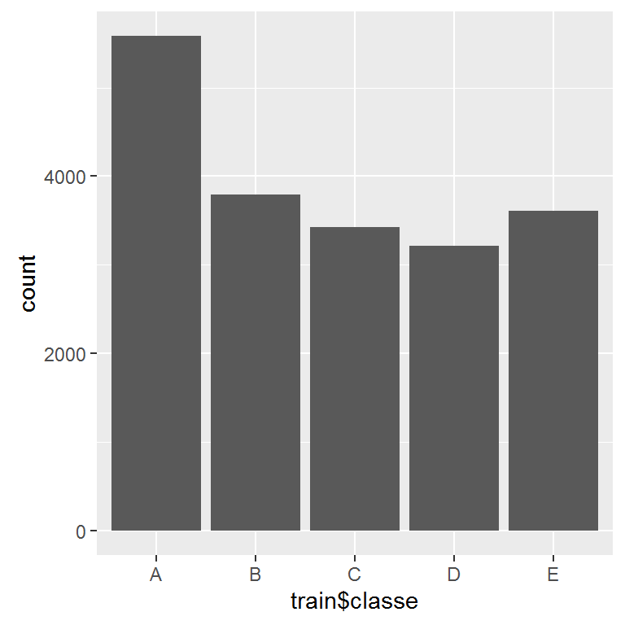

There are more class A cases than B, C, D, E, which are all at the same level

- Checking classe by **user_name** : maybe an user performs better than the others?

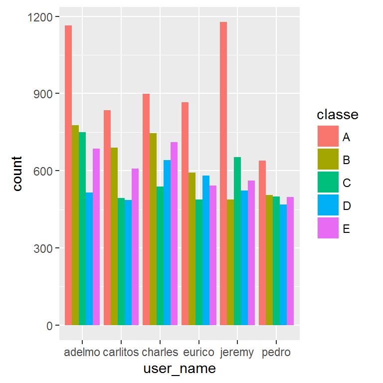

Some users different distributions than other, like pedro, who has almost as many movements class A as B,C,D,E. While users like jeremy have mainly class A and C movements.

What’s the distribution of the user_name? any need for pre-processing?

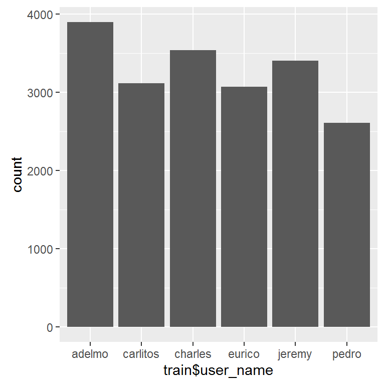

```r
qplot(train$user_name)
```

Somewhat uniform distribution. The user_name variable is pertinent to be included in the analysis.

- Let’s check the **new_window** variable

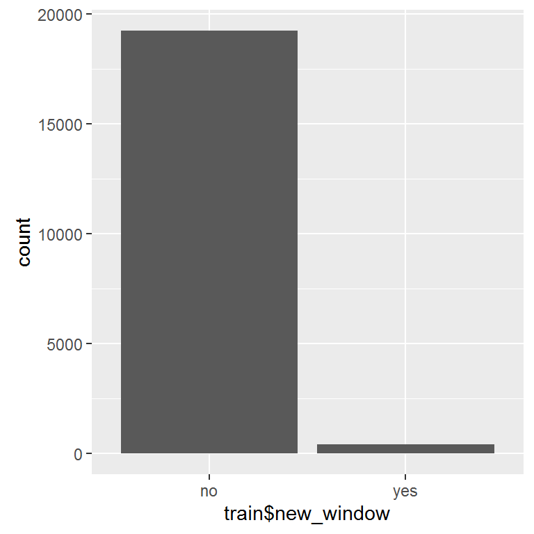

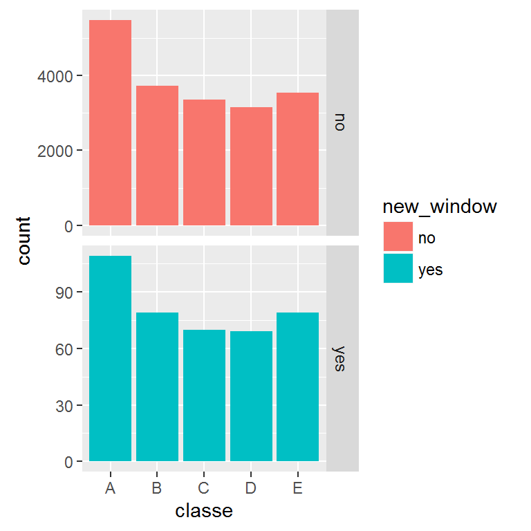

The “No” and “yes” values have same variability for all classes

What about by user?

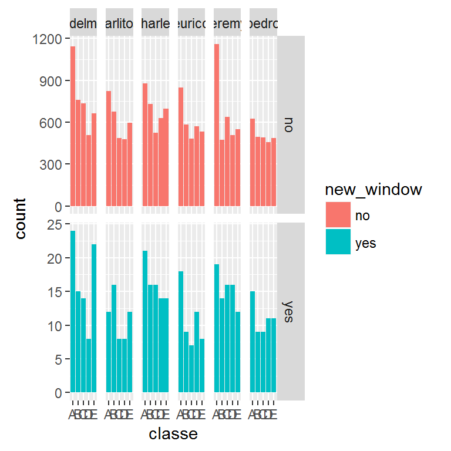

Although the “new_window” variable changes distributions of some users, so it is better to keep it in

- Checking a few distributions in order to get some perspective of variables importance and “usability”

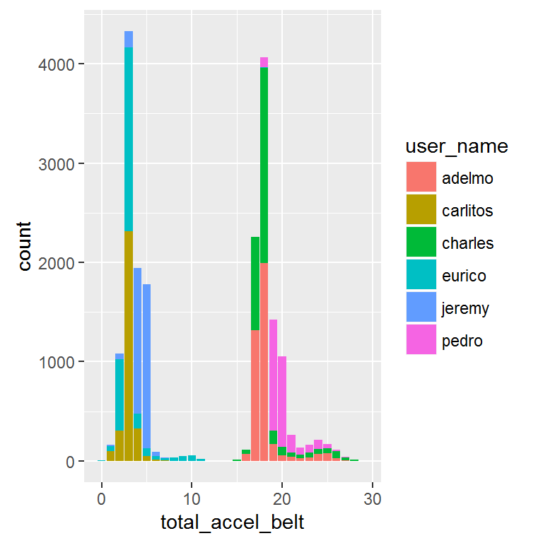

The distribution presents two gaussian-like courbes, which are just due to different users. This is a proof that including the user name is very important. Features variability change for user to user

- Checking a few last vairables:

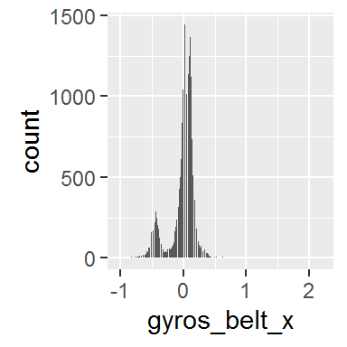

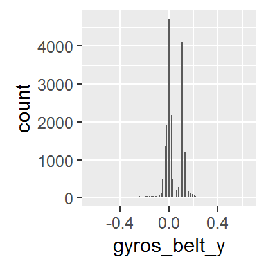

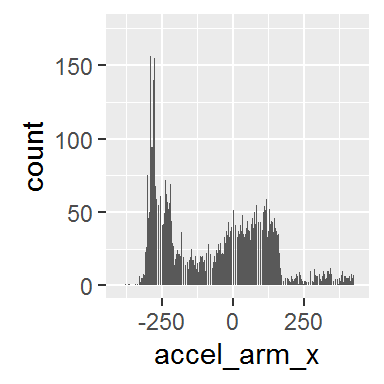

All with beatiful distributions from the accelerometers… So everything looks good, let’s move forward to creating a model

# Modelisation phase

First, some pre-processing:

### Pre-processing

- **Checking near-zero variance variables**

```r
library(caret)
nearZeroVar(train,saveMetrics = TRUE)
```

[output not shown]

“new_window” is the only near zero variance variable. We’ve seen this before, but decide to keep it since the variable seems to have some relationship with classe, when split by user_name.

Let’s check some general statistics from the data:

```r
summary(train)
```

[output not shown]

**==>** Some variables have very large values (>1000) while others are between (-5,5)

#### Standardization might be needed.

Building preprocessing object, and applying it to train & test datasets

```r
preProc <- preProcess(train, method = c("center","scale"))
trainPreProc <- predict(preProc, train)
testPreProc <- predict(preProc, test)
```

Now that everything is set, the data is clean and preprocessed, let’s train some models:

```
set.seed(10)
```

The train dataset is not modified, and used in it’s totality. To estimate the generalization error, other technique wil be used:

The caret package takes care of cross-validation. By default it applies a bootstrap cross validation, which will give us the out-of-sample or generalizastion error.

#### Training a simple CART tree

```r
  cart <- train(classe~., method="rpart", data=train)
  #Default bootstrapping used
  cart
```

What’s the Accuracy?

[output not shown]

Now, even though the accuracy is really low,we can predict over the test observations.

```
  cartpred <- predict(cart, test)
  cartpred
```

The same exact process is repeated for the CART model trained in the preprocessed data. The same transformation is applied to the test data to get the predictions

[output not shown]

**==>** The performance of CART (accuracy ~= 50%) is pretty low whether with preprocessing or not.

Now the same exact process is repeated for LDA

### Training a linear discriminant analysis

```r
#training linear discriminant analysis
lda <- train(classe~., method="lda", data=train)
  lda
  #printing Accuracy
  lda$results[2]
  #Predicting test
  ldapred <- predict(lda, test)
#With transformation (standardization)
ldaPreProc <- train(classe~., method="lda", data=trainPreProc)
  ldaPreProc
  #printing Accuracy
  ldaPreProc$results[2]
  #==> Slightly better Accuracy with preprocessing
  #Predicting test
  ldapredPreProc <- predict(ldaPreProc, testPreProc)
```

**==>** Accuracy is considerably larger with LDA than CART (85% vs 50%). It also improves with preprocessing (85.423% and 85.475%).

So wrapping up the results, this gives:

| Method | Dataset | Accuracy |
| --- | --- | --- |
| LDA | Raw | 0.8542367 |
| LDA | Preprocesssed | **0.8547509** |
| CART | Raw | 0.5152305 |
| CART | Preprocesssed | 0.5105094 |